# Semesterbegleitende Abgabe WiSe2026-27

# Statistik im Bachelor Wirtschaftsinformatik

Dozent_innen: Martin Spott, Michael Heimann, Anja Hirsch  
Stand: 17.11.2026

**Gruppe:**

Gruppe D

**Autor_innen:**

Jakob Fahr  
Anahita Karimi  
David Marcel Mayer  
Timo Wahl

## Einleitung

In diesem Semester beschäftigen wir uns mit Kraftstoffpreisen in Berlin. Dazu benutzen wir Daten von der Organisation Tankerkönig [1], die jede Preisänderung angeschlossener Tankstellenbetreiber_innen mit Zeitstempel protokolliert. In der Datei *tankerkoenig_WiSe2026-27_1.csv* finden Sie den Ausschnitt der Daten, den Sie für die Aufgaben benutzen sollen. Dabei haben wir für jede Tankstelle und jede Stunde den Median der von Tankerkönig registrierten Preisänderungen der Kraftstoffe Diesel und E10 ermittelt.

### Regeln

Arbeiten Sie in Ihrer Moodlegruppe von bis zu vier Studierenden, die alle in derselben Übungsgruppe sein und die eine zu wählende Abgabe auch in den zugehörigen Übungen vorstellen müssen (Terminkalender folgt). Jede/r von Ihnen hat in Moodle nur Zugriff auf die Gruppeneinteilung Ihrer in LSF festgelegten Übungsgruppe, wo Sie sich in einer Gruppe eintragen müssen, um Punkte zu bekommen.

Bearbeiten Sie die Aufgaben fortlaufend in diesem RMarkdown-Dokument und **geben es bei jeder Teilabgabe komplett als RMarkdown- und als mit Knit übersetztes HTML-Dokument ab**. Stellen Sie sicher, dass das RMarkdown-Dokument auch für uns lauffähig ist. Gehen Sie dazu davon aus, dass sich auf unseren Rechnern die Daten im selben Verzeichnis befinden werden wie Ihr RMarkdown-Dokument.

Benutzen Sie nur Verfahren und Techniken, die wir in der Vorlesung besprochen haben. Sie können aber gerne komplexere Visualisierungen einsetzen, wenn dies sinnvoll erscheint.

Erklären Sie kurz Ihr Vorgehen vor jedem Codeabschnitt und interpretieren die Ergebnisse danach. Schreiben Sie Erklärungen/Interpretationen in Textform zwischen die Codeblöcke, nicht als Kommentare in die Codeblöcke. Sie können den Code aber gerne zusätzlich knapp kommentieren.

Für jede weitere Woche bekommen Sie eine Aufgabenstellung in RMarkdown, die Sie bitte in diesem Dokument fortlaufend anhängen und dort bearbeiten. Geben Sie immer das gesamte Dokument einschließlich der vorangehenden Aufgaben ab, da die Aufgaben teilweise aufeinander aufbauen und Sie vorangehende Lösungen später benötigen.

## Woche 1 – 27.10.2026

Beschreiben Sie zwischen den Codeblöcken in Textform, was Sie warum tun und was Sie herausfinden.

1. Importieren Sie die Daten.
2. Beschreiben Sie die Daten. Was sind die Merkmale, was die Merkmalsträger?
3. Geben Sie für alle Merkmale an, ob sie qualitativ/quantitativ, diskrekt/stetig und auf welchen Skalen sie definiert sind.
4. Berechnen Sie für das Merkmal `brand` (Marke) die Tabellen mit absoluter und relativer Häufigkeit.
5. Stellen Sie die Tabelle absoluter Häufigkeit von `brand` als Balkendiagramm dar. Beschriften Sie alle Axen und geben dem Diagramm eine Überschrift.
6. Was bedeuten die absoluten Häufigkeiten im Kontext unserer Daten? Warum gibt es Unterschiede zwischen den Werten der verschiedenen Marken?

### a. Datenimport

Die Daten liegen im CSV Format. Wir lesen sie mit `read.csv()` ein und speichern sie unter dem Namen `tanken`, damit wir sie in den folgenden Aufgaben auswerten können.

```r
   tanken <- read.csv("tankerkoenig_WiSe2026-27_1.csv")
```

Der Datensatz enthält 478274 Zeilen und 13 Spalten.

### b. Beschreibung der Daten

Um uns einen Überblick zu verschaffen, lassen wir uns die ersten Zeilen und die Struktur der Daten anzeigen.

```r
head(tanken)
```

```
##   X                                   id       date  time            name brand
## 1 0 005056ba-7cb6-1ed2-bceb-6d1d63fd4d20 2025-02-01 07:30 star Tankstelle  STAR
## 2 1 005056ba-7cb6-1ed2-bceb-6d1d63fd4d20 2025-02-01 08:30 star Tankstelle  STAR
## 3 2 005056ba-7cb6-1ed2-bceb-6d1d63fd4d20 2025-02-01 09:30 star Tankstelle  STAR
## 4 3 005056ba-7cb6-1ed2-bceb-6d1d63fd4d20 2025-02-01 10:30 star Tankstelle  STAR
## 5 4 005056ba-7cb6-1ed2-bceb-6d1d63fd4d20 2025-02-01 11:30 star Tankstelle  STAR
## 6 5 005056ba-7cb6-1ed2-bceb-6d1d63fd4d20 2025-02-01 12:30 star Tankstelle  STAR
##                  street house_number post_code opening_time closing_time
## 1 Finckensteinallee 133         <NA>     12205        07:00        22:00
## 2 Finckensteinallee 133         <NA>     12205        07:00        22:00
## 3 Finckensteinallee 133         <NA>     12205        07:00        22:00
## 4 Finckensteinallee 133         <NA>     12205        07:00        22:00
## 5 Finckensteinallee 133         <NA>     12205        07:00        22:00
## 6 Finckensteinallee 133         <NA>     12205        07:00        22:00
##   e10_median diesel_median
## 1         NA            NA
## 2       1779          1704
## 3       1709          1639
## 4       1684          1609
## 5       1649          1589
## 6       1679          1609
```

```r
str(tanken)
```

```
## 'data.frame':    478274 obs. of  13 variables:
##  $ X            : int  0 1 2 3 4 5 6 7 8 9 ...
##  $ id           : chr  "005056ba-7cb6-1ed2-bceb-6d1d63fd4d20" "005056ba-7cb6-1ed2-bceb-6d1d63fd4d20" "005056ba-7cb6-1ed2-bceb-6d1d63fd4d20" "005056ba-7cb6-1ed2-bceb-6d1d63fd4d20" ...
##  $ date         : chr  "2025-02-01" "2025-02-01" "2025-02-01" "2025-02-01" ...
##  $ time         : chr  "07:30" "08:30" "09:30" "10:30" ...
##  $ name         : chr  "star Tankstelle" "star Tankstelle" "star Tankstelle" "star Tankstelle" ...
##  $ brand        : chr  "STAR" "STAR" "STAR" "STAR" ...
##  $ street       : chr  "Finckensteinallee 133" "Finckensteinallee 133" "Finckensteinallee 133" "Finckensteinallee 133" ...
##  $ house_number : chr  NA NA NA NA ...
##  $ post_code    : int  12205 12205 12205 12205 12205 12205 12205 12205 12205 12205 ...
##  $ opening_time : chr  "07:00" "07:00" "07:00" "07:00" ...
##  $ closing_time : chr  "22:00" "22:00" "22:00" "22:00" ...
##  $ e10_median   : int  NA 1779 1709 1684 1649 1679 1699 1684 1709 1699 ...
##  $ diesel_median: int  NA 1704 1639 1609 1589 1609 1629 1619 1639 1619 ...
```

Der Datensatz enthält stündliche Kraftstoffpreise von Berliner Tankstellen. Der Merksmalsträger ist eine Tankstelle in einer bestimmten Stunde an einem bestimmten Tag. Grundgesamtheit sind alle Stunden der 78 Tankstellen in Berlin von Februar 2025 bis Januar 2026. Merkmale sind die Spalten: - `X`: die Zeilennummer - `id`: eindeutige ID der Tankstelle - `date`, `time`: Datum und Stunde - `name`, `brand`: Name und Marke der Tankstelle - `street`, `house_number`, `post_code`: Adresse der Tankstelle - `opening_time`, `closing_time`: Öffnungs und Schließzeit - `e10_median`, `diesel_median`: Median der Preise für E10 und Diesel in dieser Stunde. Die Preise sind in Euro pro Liter angegeben, aber ohne Komma.

Bei einigen Zeilen fehlen die Preise (`NA`).

### c. Merkmalstypen

| Merkmal | qualitativ/quantitativ | diskret/stetig | Skala |
| --- | --- | --- | --- |
| `X` | quantitativ | diskret | Ordinalskala |
| `id` | qualitativ | diskret | Nominalskala |
| `date` | quantitativ | diskret | Intervallskala |
| `time` | quantitativ | diskret | Intervallskala |
| `name` | qualitativ | diskret | Nominalskala |
| `brand` | qualitativ | diskret | Nominalskala |
| `street` | qualitativ | diskret | Nominalskala |
| `house_number` | qualitativ | diskret | Nominalskala |
| `post_code` | qualitativ | diskret | Nominalskala |
| `opening_time` | quantitativ | diskret | Intervallskala |
| `closing_time` | quantitativ | diskret | Intervallskala |
| `e10_median` | quantitativ | quasi-stetig | Verhältnisskala |
| `diesel_median` | quantitativ | quasi-stetig | Verhältnisskala |

Postleitzahl, Hausnummer und id bestehen zwar teilweise aus Ziffern, sind aber nur Bezeichnungen, mit denen man nicht rechnen kann. Deshalb sind sie qualitativ und nominal. Datum und Uhrzeiten sind intervallskaliert. Abstände sind sinnvoll, aber der Nullpunkt ist willkürlich. Die Preise sind verhältnisskaliert, weil 0 € ein echter Nullpunkt ist. Sie sind quasi-stetig, weil sie gerundet angegeben werden.

### d. Häufigkeiten der Marken

Wir zählen mit `table()`, wie oft jede Marke im Datensatz vorkommt (absolute Häufigkeit), und rechnen das mit `prop.table()` in Anteile um (relative Häufigkeit). Die Anteile runden wir mit `round()` auf drei Nachkommastellen.

```r
brand_abs <- table(tanken$brand)
brand_abs
```

```
##
##      AGIP ENI          ARAL          ESSO           HEM           JET
##         23595         52758         34385         35734         30489
##         Shell        Sprint          STAR TotalEnergies
##         95828         36423        102928         66134
```

```r
brand_rel <- prop.table(brand_abs)
round (brand_rel, 3)
```

```
##
##      AGIP ENI          ARAL          ESSO           HEM           JET
##         0.049         0.110         0.072         0.075         0.064
##         Shell        Sprint          STAR TotalEnergies
##         0.200         0.076         0.215         0.138
```

### e. Balkendiagramm

Da `brand` ein qualitatives Merkmal ist, stellen wir die absoluten Häufigkeiten als Balkendiagramm dar. Damit alle Markennamen lesbar sind, verkleinern wir sie (mit `cex.names`) und drehen sie senkrecht (mit `las = 2`).

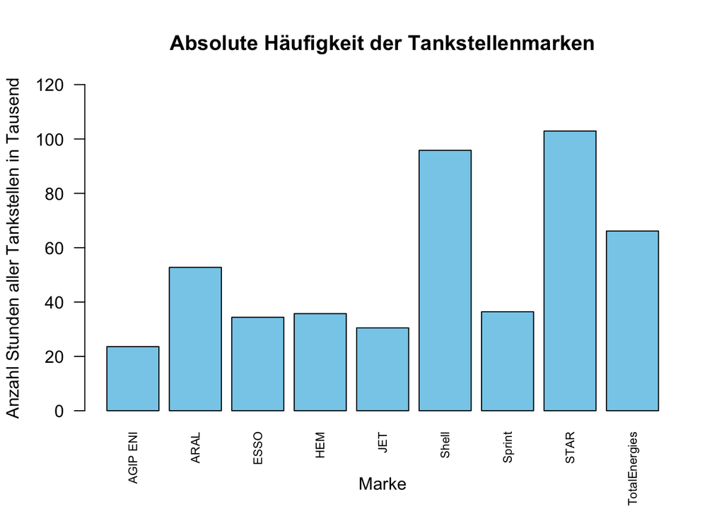

```r
barplot(brand_abs/1000,
        main = "Absolute Häufigkeit der Tankstellenmarken",
        xlab = "Marke",
        ylab = "Anzahl Stunden aller Tankstellen in Tausend",
        ylim = c(0, 120),
        cex.names = 0.7,
        las = 2,
        col = "skyblue")
```

Auf der x Achse sind die Tankstellenmarken. Auf der y Achse ist die absolute Häufigkeit dargestellt, also die Anzahl der Stunden, für die im Datensatz ein Preis einer Tankstelle dieser Marke vorliegt (zusammengezählt über alle Tankstellen der Marke und das ganze Jahr). Jeder Balken steht für eine Marke, und seine Höhe zeigt, wie oft diese Marke im Datensatz vorkommt. Am häufigsten kommt STAR vor, dicht gefolgt von Shell. Mit Abstand folgt TotalEnergies, am seltensten ist AGIP ENI.

### f. Interpretation der Häufigkeiten

Die absolute Häufigkeit einer Marke gibt an, für wie viele Stunden im Datensatz ein Preis einer Tankstelle dieser Marke vorliegt, zusammengezählt über alle Berliner Tankstellen der Marke im Zeitraum von Februar 2025 bis Januar 2026.

Die Unterschiede können vor allem durch die Anzahl der Tankstellen je Marke entstehen. STAR hat im Datensatz 17 Tankstellen, Shell 15, AGIP ENI dagegen nur 4. Je mehr Tankstellen eine Marke hat, desto mehr Stunden kommen zusammen. Außerdem sind die Öffnungszeiten auch relevant, je länger eine Tankstelle geöffnet hat, desto mehr Stunden mit Preisen gibt es im Datensatz.

```r
tankstellen <- unique(tanken[, c("id", "brand")])
table(tankstellen$brand)
```

```
##
##      AGIP ENI          ARAL          ESSO           HEM           JET
##             4             9             6             5             5
##         Shell        Sprint          STAR TotalEnergies
##            15             6            17            11
```

**—Fügen Sie hier kommende Aufgabenbeschreibungen mit Lösungen ein —**

## Woche 2

1. Bestimmen Sie, wie viele Werte bei jedem Merkmal im Datensatz fehlen (NA). Finden Sie mit Detektivarbeit heraus, welche Eigenschaft die Datensätze mit den fehlenden Werten haben und wie man die fehlenden mit sinnvollen Werten ersetzen kann. Das Ersetzen müssen Sie nur erklären, nicht implementieren.
2. Bestimmen Sie, zu welchen Uhrzeiten Messungen durchgeführt wurden und jeweils wie viele. Finden Sie mit Detektivarbeit heraus, welche Eigenschaften die Datensätze mit Messungen haben, die nicht bei voller Stunde vorgenommen wurden. Runden Sie die Zeit von allen Datensätzen zur nächsten vollen Stunde ab (streichen die Minuten), um später einfacher mit den Daten arbeiten zu können.
3. Finden Sie heraus, ob Merkmalsträger komplett fehlen. Wenn ja, können Sie ein Muster für das Fehlen erkennen?

### a. Fehlende Werte

Mit `is.na()` wird für jeden Wert geprüft, ob er fehlt.`colSums()` zählt dann die fehlenden Werte für jede Spalte. Mit `mean()` berechnen wir zusätzlich den Anteil der fehlenden Preise.

```r
colSums(is.na(tanken))
```

```
##             X            id          date          time          name
##             0             0             0             0             0
##         brand        street  house_number     post_code  opening_time
##             0             0         85868             0             0
##  closing_time    e10_median diesel_median
##             0         28151         28151
```

```r
mean(is.na(tanken$e10_median))
```

```
## [1] 0.05885957
```

```r
mean(is.na(tanken$diesel_median))
```

```
## [1] 0.05885957
```

Fehlende Werte gibt es nur bei `house_number`, `e10_median` und `diesel_median`. Bei `house_number` fehlen 85868 Werte. Das liegt daran, dass die Hausnummer schon in `street` steht. Bei `e10_median` und `diesel_median` fehlen jeweils 28151 Werte, also etwa 5,9 % aller Zeilen. Da es bei beiden genau gleich viele sind, fehlen wahrscheinlich immer beide Preise gleichzeitig.

Um herauszufinden, was die Zeilen mit fehlenden Preisen gemeinsam haben, filtern wir nur die Zeilen, in denen `e10_median` fehlt, und speichern sie als `fehlende_preise`. Mit `head()` schauen wir uns die ersten 15 Zeilen an.

```r
fehlende_preise <- tanken[is.na(tanken$e10_median) ,]
head(fehlende_preise, 15)
```

```
##         X                                   id       date  time            name
## 1       0 005056ba-7cb6-1ed2-bceb-6d1d63fd4d20 2025-02-01 07:30 star Tankstelle
## 98     97 005056ba-7cb6-1ed2-bceb-6d1d63fd4d20 2025-02-08 07:30 star Tankstelle
## 270   269 005056ba-7cb6-1ed2-bceb-6d1d63fd4d20 2025-02-20 07:30 star Tankstelle
## 300   299 005056ba-7cb6-1ed2-bceb-6d1d63fd4d20 2025-02-22 07:30 star Tankstelle
## 325   324 005056ba-7cb6-1ed2-bceb-6d1d63fd4d20 2025-02-24 07:30 star Tankstelle
## 340   339 005056ba-7cb6-1ed2-bceb-6d1d63fd4d20 2025-02-25 07:30 star Tankstelle
## 796   795 005056ba-7cb6-1ed2-bceb-6d1d63fd4d20 2025-03-29 07:30 star Tankstelle
## 824   823 005056ba-7cb6-1ed2-bceb-6d1d63fd4d20 2025-03-31 07:30 star Tankstelle
## 863   862 005056ba-7cb6-1ed2-bceb-6d1d63fd4d20 2025-04-03 07:30 star Tankstelle
## 877   876 005056ba-7cb6-1ed2-bceb-6d1d63fd4d20 2025-04-04 07:30 star Tankstelle
## 1017 1016 005056ba-7cb6-1ed2-bceb-6d1d63fd4d20 2025-04-14 07:30 star Tankstelle
## 1073 1072 005056ba-7cb6-1ed2-bceb-6d1d63fd4d20 2025-04-18 07:30 star Tankstelle
## 1088 1087 005056ba-7cb6-1ed2-bceb-6d1d63fd4d20 2025-04-19 07:30 star Tankstelle
## 1116 1115 005056ba-7cb6-1ed2-bceb-6d1d63fd4d20 2025-04-21 07:30 star Tankstelle
```

[output cut: 33 more lines]

In allen Zeilen fehlt auch `diesel_median`. Außerdem ist die Uhrzeit immer 07:30, also die erste Stunde nach der Öffnung um 07:00. Das sind aber alles Zeilen von derselben Tankstelle. Deshalb prüfen wir mit `table()`, ob das Muster auch bei den anderen Tankstellen gilt.

```r
table(fehlende_preise$time)
```

```
##
## 00:00 01:00 02:00 03:00 04:00 05:00 06:00 06:15 06:30 07:00 07:30 08:00 08:30
##  3115  3051  3053  3031  3818  2292  1681     3     6  2822   194   436     4
## 09:00 09:30 10:00 10:30 11:00 11:30 12:00 12:30 13:00 13:30 14:00 14:30 15:00
##   371     2   364     2   359     2   351     2   332     2   327     2   322
## 15:30 16:00 16:30 17:00 17:30 18:00 18:30 19:00 19:30 20:00 20:30 21:00 21:30
##     2   324     2   310     2   311     1   312     1   304     1   289     1
## 22:00 22:30 23:00
##   283     1    63
```

```r
table(fehlende_preise$opening_time)
```

```
##
## 00:00 04:00 05:00 06:00 07:00 08:00
## 16875   783  1097  7633  1751    12
```

Die meisten fehlenden Preise gibt es nachts und früh morgens zwischen 00:00 und 07:00 Uhr. Tagsüber fehlen nur etwa 300 Werte pro Stunde. Bei `opening_time` sieht man, dass 16875 der fehlenden Preise von Tankstellen kommen, die um 00:00 öffnen, also 24 Stunden offen haben. Danach kommen die Tankstellen, die um 06:00 öffnen.

Die Preise fehlen also immer am Anfang des Tages. Eine Tankstelle hat so lange keinen Preis, bis sie an dem Tag zum ersten Mal ihren Preis ändert. Bei Tankstellen, die 24 Stunden offen haben, ist das nachts, bei den anderen in der ersten Stunde nach dem Öffnen. Natürlich gibt es in dieser Zeit trotzdem einen Preis, er wurde nur noch nicht gemeldet. Deshalb konnte für diese Stunde kein Median berechnet werden.

**Ersetzen der fehlenden Werte:**

Weil ein Preis so lange gilt, bis er geändert wird, kann man einen fehlenden Wert durch den letzten bekannten Preis derselben Tankstelle ersetzen, also durch den letzten Preis vom Vortag. Dabei muss man darauf achten, nur Werte derselben Tankstelle zu nehmen und nicht einfach die Zeile darüber.

### b. Uhrzeiten der Messungen

Zuerst wird mit `table()` angezeigt, zu welchen Uhrzeiten Messungen vorliegen und wie viele es jeweils sind. Mit `length(unique())` zählen wir außerdem, wie viele verschiedene Uhrzeiten im Datensatz vorkommen.

```r
length(unique(tanken$time))
```

```
## [1] 58
```

```r
table(tanken$time)
```

```
##
## 00:00 01:00 02:00 03:00 04:00 05:00 06:00 06:15 06:30 07:00 07:15 07:30 08:00
##  3119  3064  3072  3050  3836  8934 21663   689   598 24774   694   992 25144
## 08:15 08:30 09:00 09:15 09:30 10:00 10:15 10:30 11:00 11:15 11:30 12:00 12:15
##   692  1039 25222   701  1040 25320   690  1040 25257   697  1044 25226   694
## 12:30 13:00 13:15 13:30 14:00 14:15 14:30 15:00 15:15 15:30 16:00 16:15 16:30
##  1032 25238   683  1036 25329   694  1033 25263   696  1041 25220   689  1041
## 17:00 17:15 17:30 18:00 18:15 18:30 19:00 19:15 19:30 20:00 20:15 20:30 21:00
## 24956   695  1044 25021   698  1039 24946   699  1035 24927   698  1049 23691
## 21:15 21:30 22:00 22:15 22:30 23:00
##   695  1046 21390   703   684  5972
```

Im Datensatz kommen 58 verschiedene Uhrzeiten vor. Neben den 24 vollen Stunden gibt es auch Messungen um xx:15 und xx:30

Die Uhrzeit liegt als Text im Format `"xx:xx"` vor. Mit `sub()` wird der Doppelpunkt durch einen leeren Text ersetzt, also gelöscht, sodass aus `"07:30"` die Zahl `730` wird. Mit der Ganzzahldivision `%/%` erhält man daraus die Stunde und mit dem Rest der Division `%%` die Minute

```r
zeit   <- as.integer(sub(":", "", tanken$time))
stunde <- zeit %/% 100
minute <- zeit %% 100

table(minute)
```

```
## minute
##      0     15     30
## 449634  11807  16833
```

Von den 478274 Messungen wurden 449634 zur vollen Stunde durchgeführt, 11807 zur Viertelstunde und 16833 zur halben Stunde.

```r
voll       <- tanken[minute == 0, ]
nicht_voll <- tanken[minute != 0, ]

table(nicht_voll$street)
```

```
##
##   Altentreptower Straße   Finckensteinallee 133      Steglitzer Damm 77
##                    5908                    5144                    5784
##       Teltower Damm 164 Waidmannsluster Damm 54
##                    5905                    5899
```

```r
length(unique(nicht_voll$id))
```

```
## [1] 5
```

```r
table(nicht_voll$time)
```

```
##
## 06:15 06:30 07:15 07:30 08:15 08:30 09:15 09:30 10:15 10:30 11:15 11:30 12:15
##   689   598   694   992   692  1039   701  1040   690  1040   697  1044   694
## 12:30 13:15 13:30 14:15 14:30 15:15 15:30 16:15 16:30 17:15 17:30 18:15 18:30
##  1032   683  1036   694  1033   696  1041   689  1041   695  1044   698  1039
## 19:15 19:30 20:15 20:30 21:15 21:30 22:15 22:30
##   699  1035   698  1049   695  1046   703   684
```

```r
table(nicht_voll$street, minute[minute != 0])
```

```
##
##                             15   30
##   Altentreptower Straße   5908    0
##   Finckensteinallee 133      0 5144
##   Steglitzer Damm 77         0 5784
##   Teltower Damm 164          0 5905
##   Waidmannsluster Damm 54 5899    0
```

Die meisten Messungen erfolgten zur vollen Stunde. Die Ausnahmen stammen ausschließlich von 5 Tankstellen, die ihre Preise immer zu einer festen Minute melden:

- **xx:15**: Altentreptower Straße, Waidmannsluster Damm 54
- **xx:30**: Finckensteinallee 133, Steglitzer Damm 77, Teltower Damm 164

Zum Schluss runden wir alle Uhrzeiten auf die volle Stunde ab, indem wir die Minuten streichen. Die Stunde haben wir oben bereits berechnet, bisher aber nur in der Variable `stunde` gespeichert. Mit `sprintf("%02d:00", stunde)` machen wir daraus wieder eine Uhrzeit im Format `"xx:00"`, wobei `%02d` die Stunde zweistellig mit führender Null schreibt.

```r
tanken$time <- sprintf("%02d:00", stunde)
table(tanken$time)
```

```
##
## 00:00 01:00 02:00 03:00 04:00 05:00 06:00 07:00 08:00 09:00 10:00 11:00 12:00
##  3119  3064  3072  3050  3836  8934 22950 26460 26875 26963 27050 26998 26952
## 13:00 14:00 15:00 16:00 17:00 18:00 19:00 20:00 21:00 22:00 23:00
## 26957 27056 27000 26950 26695 26758 26680 26674 25432 22777  5972
```

### c. Komplett fehlende Merkmalsträger

Ein Merkmalsträger ist eine Tankstelle in einer bestimmten Stunde an einem bestimmten Tag. Zuerst wird geprüft, wie viele Zeilen es theoretisch geben müsste, wenn für alle 78 Tankstellen an allen 365 Tagen jede der 24 Stunden vorhanden wäre.

```r
78 * 365 * 24
```

```
## [1] 683280
```

```r
nrow(tanken)
```

```
## [1] 478274
```

Bei 24 Stunden pro Tag gäbe es 683280 Merkmalsträger, wir haben aber nur 478274 Zeilen. Es fehlen also 205006 Stunden.

Grund: Öffnungszeiten. Es muss geprüft werden ob es im Datensatz überhaupt Zeilen außerhalb der Öffnungszeiten gibt, und dann muss berechnet werden, wie viele Stunden die Tankstellen insgesamt geöffnet haben.

```r
open_stunde  <- as.integer(sub(":00", "", tanken$opening_time))
close_stunde <- as.integer(sub(":00", "", tanken$closing_time))


sum(stunde < open_stunde)
```

```
## [1] 0
```

```r
sum(stunde >= close_stunde)
```

```
## [1] 0
```

```r
tag_info  <- tanken[!duplicated(tanken[, c("id", "date")]), ]
tag_open  <- as.integer(sub(":00", "", tag_info$opening_time))
tag_close <- as.integer(sub(":00", "", tag_info$closing_time))

sum(tag_close - tag_open)
```

```
## [1] 506484
```

```r
sum(tag_close - tag_open) - nrow(tanken)
```

```
## [1] 28210
```

Außerhalb der Öffnungszeiten gibt es 0 Zeilen. Insgesamt hatten alle Tankstellen im Jahr zusammen 506484 Stunden geöffnet. Damit fehlen schon mal $683280 - 506484 = 176796$ Merkmalsträger einfach deshalb, weil die Tankstellen nachts geschlossen hatten.

Allerdings fehlen auch innerhalb der Öffnungszeiten noch $506484 - 478274 = 28210$ Zeilen komplett. Um zu sehen, wann diese Zeilen fehlen, wird die erste Tankstelle an den ersten beiden Tagen näher betrachten. Des Weiteren wird geschaut für jede Stunde des Tages, wie viele geöffnete Stunden im Datensatz fehlen.

```r
tanken[1:14, c("date", "time", "opening_time", "closing_time", "e10_median")]
```

```
##          date  time opening_time closing_time e10_median
## 1  2025-02-01 07:00        07:00        22:00         NA
## 2  2025-02-01 08:00        07:00        22:00       1779
## 3  2025-02-01 09:00        07:00        22:00       1709
## 4  2025-02-01 10:00        07:00        22:00       1684
## 5  2025-02-01 11:00        07:00        22:00       1649
## 6  2025-02-01 12:00        07:00        22:00       1679
## 7  2025-02-01 14:00        07:00        22:00       1699
## 8  2025-02-01 15:00        07:00        22:00       1684
## 9  2025-02-01 16:00        07:00        22:00       1709
## 10 2025-02-01 17:00        07:00        22:00       1699
## 11 2025-02-01 18:00        07:00        22:00       1679
## 12 2025-02-01 19:00        07:00        22:00       1684
## 13 2025-02-01 20:00        07:00        22:00       1704
## 14 2025-02-01 21:00        07:00        22:00       1684
```

```r
offen_je_stunde <- sapply(0:23, function(h) sum(tag_open <= h & h < tag_close))
offen_je_stunde - as.integer(table(tanken$time))
```

```
##  [1]  166  221  213  235  229  491 1280 1435 1491 1507 1420 1472 1518 1513 1414
## [16] 1470 1520 1775 1712 1790 1796 1683 1573  286
```

Bei der ersten Tankstelle fehlt am `2025-02-01` mitten am Tag die Zeile für `13:00` Uhr (vor dem Abrunden `13:30`). Auch über den ganzen Datensatz verteilt fehlen tagsüber zwischen 06:00 und 22:00 Uhr in jeder Stunde rund 1300 bis 1800 Zeilen.

**Muster für das Fehlen der Merkmalsträger:**

1. **Geschlossene Stunden (176796 Zeilen):** Wenn eine Tankstelle geschlossen hat, wird für diese Stunden gar keine Zeile im Datensatz angelegt.
2. **Keine Preisänderung in dieser Stunde (28210 Zeilen):** Tankerkönig zeichnet nur Preisänderungen auf. Am Anfang des Tages (nach der Öffnung bis zur ersten Preismeldung) wurden die Stunden ohne Meldung zwar noch als Zeilen mit `NA` aufgefüllt (siehe Aufgabe a). Sobald an einem Tag aber der erste Preis gemeldet wurde, fehlt eine spätere Stunde komplett als Zeile im Datensatz, wenn die Tankstelle in dieser Stunde ihren Preis nicht geändert hat.

## Woche 3 – 10.11.2026

1. Erstellen Sie vollständig beschriftete Histogramme für die Merkmale `e10_median` und `diesel_median` und überlagern diese zum besseren Vergleich in einem Diagramm. Dazu können Sie auch Bibliotheken wie ggplot2 und plotly betrachten.
2. Bestimmen Sie Fünf- oder Sechs-Punkte-Zusammenfassungen der Merkmale `e10_median` und `diesel_median` und erstellen zugehörige Boxplots mit Ausreißererkennung.
3. Vergleichen Sie anhand der Histogramme, der Fünf- oder Sechs-Punkte-Zusammenfassungen sowie der Boxplots die Werteverteilungen von `e10_median` und `diesel_median`.
4. Extrahieren Sie die Ausreißer von `e10_median` und `diesel_median`. Finden Sie mit Detektivarbeit heraus,
- ob es ein Muster für die Ausreißer gibt, z.B. wann sie wo auftreten
- ob die Ausreißer echte oder falsche Werte sind.

### a. Histogramme

Beim Anschauen der Daten ist uns aufgefallen, dass es beim Diesel Preise von 0 € gibt. Das kann kein echter Preis sein, deshalb schauen wir uns diese Zeilen zuerst an. Mit `!is.na()` werden Zeilen ohne Preis dabei ausgelassen.

```r
tanken[!is.na(tanken$diesel_median) & tanken$diesel_median == 0,
       c("date", "time", "brand", "street", "e10_median", "diesel_median")]
```

```
##            date  time brand                street e10_median diesel_median
## 469  2025-03-06 07:00  STAR Finckensteinallee 133       1759             0
## 479  2025-03-06 19:00  STAR Finckensteinallee 133       1599             0
## 480  2025-03-06 20:00  STAR Finckensteinallee 133       1619             0
## 2731 2025-08-13 07:00  STAR Finckensteinallee 133       1709             0
## 2736 2025-08-13 12:00  STAR Finckensteinallee 133       1629             0
## 2743 2025-08-13 19:00  STAR Finckensteinallee 133       1599             0
```

Es gibt 6 Nullpreise, alle von der Tankstelle in der Finckensteinallee 133. Sie kommen nur an zwei Tagen vor: am 06.03.2025 um 7, 19 und 20 Uhr und am 13.08.2025 um 7, 12 und 19 Uhr. E10 hat zu diesen Zeiten normale Preise und auch Diesel ist in den Stunden dazwischen normal. Die Nullen sind also Fehler in den Daten.

Deshalb setzen wir die 6 Werte auf NA. Sonst würde das Diesel-Histogramm bei 0 anfangen und man könnte die echten Preise kaum noch erkennen. Das gilt auch für alle weiteren Teilaufgaben.

```r
tanken$diesel_median[which(tanken$diesel_median == 0)] <- NA
```

Zuerst zeichnen wir mit `hist()` für E10 und Diesel jeweils ein eigenes Histogramm. Mit `col = rgb(r, g, b, 0.5)` wird die Farbe halb durchsichtig (Rot für E10, Blau für Diesel). Mit `main`, `xlab` und `ylab` geben wir Titel und Achsenbeschriftung an.

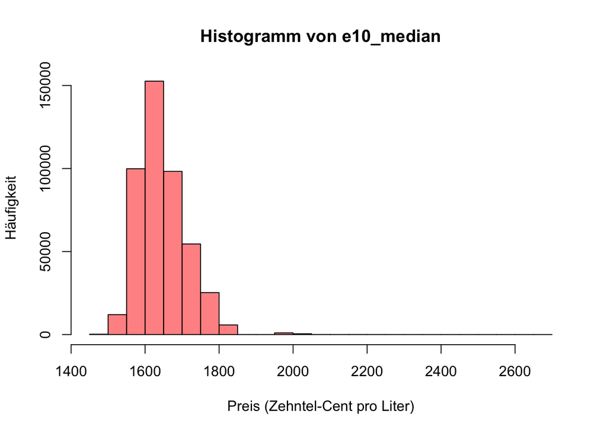

```r
hist(tanken$e10_median, col=rgb(1,0,0,0.5), xlab="Preis (Zehntel-Cent pro Liter)", ylab="Häufigkeit", main="Histogramm von e10_median")
```

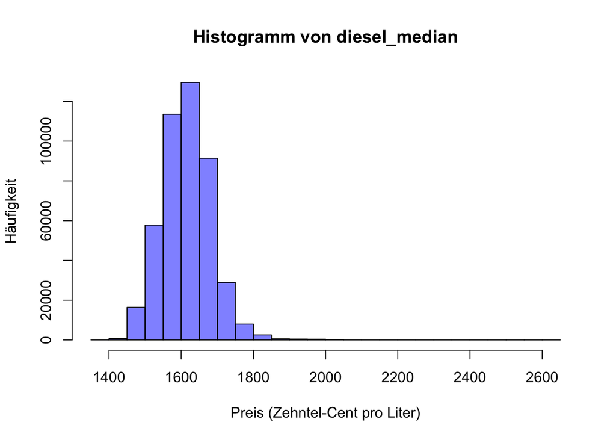

```r
hist(tanken$diesel_median, col=rgb(0,0,1,0.5), xlab="Preis (Zehntel-Cent pro Liter)", ylab="Häufigkeit", main="Histogramm von diesel_median")
```

Damit wir beide Histogramme in ein Diagramm legen können, nehmen wir ggplot2. Dafür brauchen wir die Daten in einer Tabelle mit nur zwei Spalten: `Sorte` (E10 oder Diesel) und `Preis`. Diese Tabelle nennen wir `lang`. Mit `rep(..., each = nrow(tanken))` wird in `Sorte` erst bei allen E10-Preisen „E10“ und danach bei allen Dieselpreisen „Diesel“ eingetragen.

Zum Zeichnen entfernen wir mit `na.omit()` die fehlenden Preise. In `aes()` legen wir den Preis auf die x-Achse und färben nach Sorte. Mit `binwidth = 25` und `boundary = 0` haben beide Histogramme die gleichen Klassen (1375–1400, 1400–1425, …), sonst könnte man sie nicht gut vergleichen. `alpha = 0.5` macht die Balken durchsichtig und `position = "identity"` legt sie übereinander statt sie zu stapeln. Mit `coord_cartesian()` zeigen wir nur den Bereich von 1375 bis 2000, in dem fast alle Preise liegen. Die etwa 540 E10- und 150 Dieselpreise über 2 € werden nur ausgeblendet, nicht gelöscht. Sie kommen fast alle von der Autobahntankstelle Avus (siehe d). Mit `scale_fill_manual()` nehmen wir die gleichen Farben wie oben, mit `labs()` beschriften wir das Diagramm.

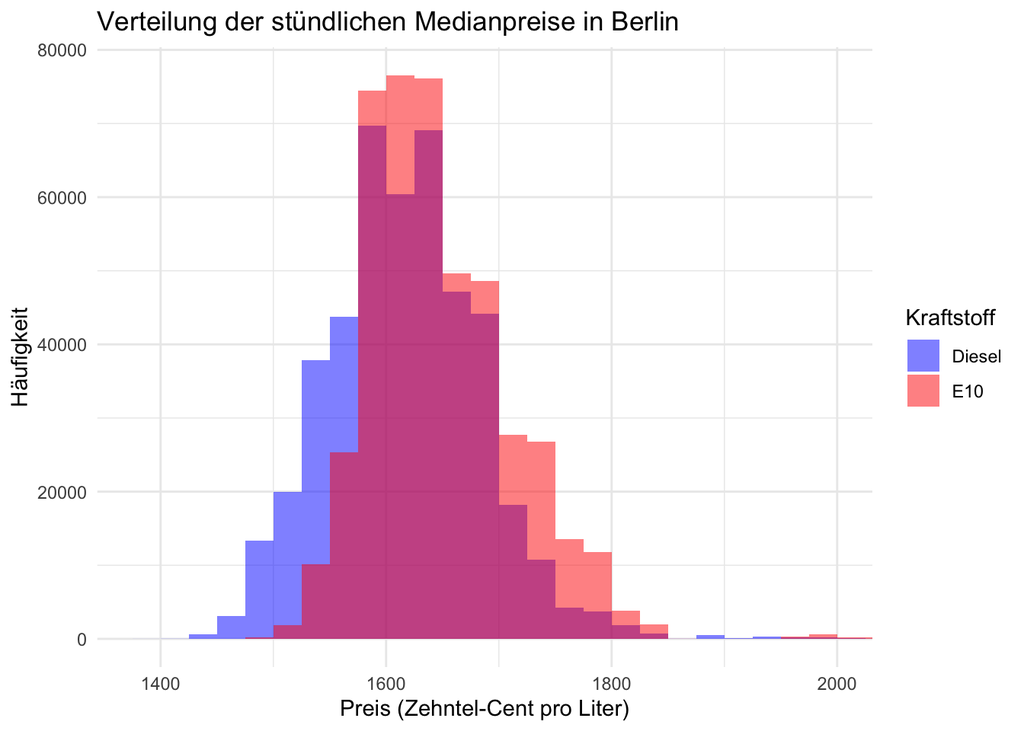

```r
library(ggplot2)
lang <- data.frame(
  Sorte = rep(c("E10", "Diesel"), each = nrow(tanken)),
  Preis = c(tanken$e10_median, tanken$diesel_median))

ggplot(na.omit(lang), aes(x = Preis, fill = Sorte)) +
  geom_histogram(binwidth = 25, boundary = 0, alpha = 0.5, position = "identity") +
  coord_cartesian(xlim = c(1375, 2000)) +
  scale_fill_manual(values = c(E10 = "red", Diesel = "blue")) +
  labs(title = "Verteilung der stündlichen Medianpreise in Berlin",
       x = "Preis (Zehntel-Cent pro Liter)", y = "Häufigkeit", fill = "Kraftstoff") +
  theme_minimal()
```

Beide Verteilungen haben nur einen Gipfel, der bei etwa 1,60 € liegt. E10 liegt insgesamt etwas weiter rechts als Diesel, ist also meistens etwas teurer. Nach links fallen beide schnell ab, nach rechts laufen sie langsam aus. Bei E10 sieht man das stärker. Diesel geht dafür weiter nach links, bis ungefähr 1,40 €.

### b. Boxplots mit Ausreißererkennung

Mit `summary()` bekommen wir die Sechs-Punkte-Zusammenfassung (Minimum, unteres Quartil, Median, Mittelwert, oberes Quartil, Maximum) und die Anzahl der NAs. `fivenum()` gibt die Fünf-Punkte-Zusammenfassung ohne Mittelwert aus. Danach zeichnen wir beide Boxplots nebeneinander. Die Box geht vom unteren bis zum oberen Quartil, der Strich in der Mitte ist der Median. Die Whisker gehen bis zum letzten Wert, der noch innerhalb von 1,5 × IQR (Interquartilsabstand) liegt. Alle Werte darüber hinaus werden als Punkte gezeichnet und sind Ausreißer. Mit `boxplot.stats()` bekommen wir die Ausreißer in `$out`. Mit `length()` zählen wir sie und mit `range()` sehen wir den kleinsten und größten Ausreißer.

```r
# Sechs-Punkte-Zusammenfassung (Min, Q1, Median, Mittelwert, Q3, Max)
summary(tanken$e10_median)
```

```
##    Min. 1st Qu.  Median    Mean 3rd Qu.    Max.     NAs
##    1484    1604    1639    1649    1689    2669   28151
```

```r
summary(tanken$diesel_median)
```

```
##    Min. 1st Qu.  Median    Mean 3rd Qu.    Max.     NAs
##    1399    1569    1619    1618    1659    2619   28157
```

```r
# Fünf-Punkte-Zusammenfassung nach Tukey
fivenum(tanken$e10_median)
```

```
## [1] 1484 1604 1639 1689 2669
```

```r
fivenum(tanken$diesel_median)
```

```
## [1] 1399 1569 1619 1659 2619
```

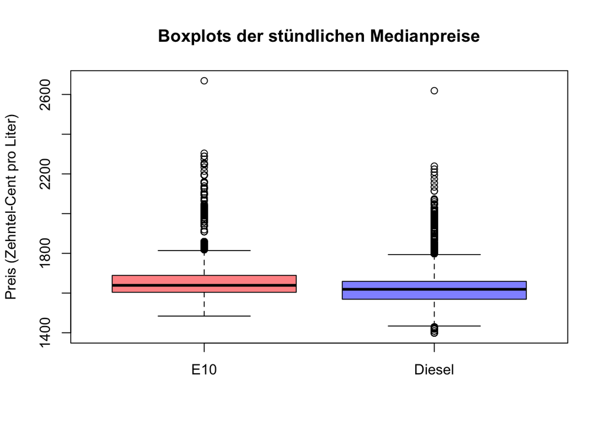

```r
boxplot(tanken$e10_median, tanken$diesel_median,
        names = c("E10", "Diesel"), col = c(rgb(1,0,0,0.5), rgb(0,0,1,0.5)),
        ylab = "Preis (Zehntel-Cent pro Liter)",
        main = "Boxplots der stündlichen Medianpreise")
```

```r
# Ausreißer anzeigen (Werte außerhalb 1,5 × IQR)
b_e10 <- boxplot.stats(tanken$e10_median)
length(b_e10$out); range(b_e10$out)
```

```
## [1] 5207
```

```
## [1] 1819 2669
```

```r
b_diesel <- boxplot.stats(tanken$diesel_median)
length(b_diesel$out); range(b_diesel$out)
```

```
## [1] 5361
```

```
## [1] 1399 2619
```

Der Median liegt bei E10 bei 1639 (1,639 €) und bei Diesel bei 1619 (1,619 €). Die Boxen sind sehr klein, die mittleren 50 % der Preise liegen also nah beieinander. Beide haben viele Ausreißer nach oben. Bei E10 sind es 5207 (von 1819 bis 2669), bei Diesel 5361 (von 1399 bis 2619). Nur Diesel hat auch Ausreißer nach unten. Die 6 Nullpreise sind nicht mehr dabei, weil wir sie in a auf NA gesetzt haben.

### c. Vergleich der Verteilungen von E10 und Diesel

Lage: E10 ist teurer als Diesel. Der Median ist bei E10 1639 und bei Diesel 1619, das sind 2 Cent Unterschied pro Liter. Beim Mittelwert sind es 3,1 Cent (1649 zu 1618). Im Histogramm sieht man das daran, dass E10 weiter rechts liegt.

Streuung: Bei beiden liegen die mittleren 50 % der Preise eng zusammen. Bei E10 von 1604 bis 1689 (IQR 85), bei Diesel von 1569 bis 1659 (IQR 90). Diesel streut also etwas mehr. Die Spannweite ist beim Diesel auch etwas größer (1220 zu 1185).

Form: Für die Lageregel aus der Vorlesung brauchen wir außer Mittelwert und Median noch den Modus. Weil die Preise stetig sind, bestimmen wir ihn über Klassen. Wir nehmen die gleichen Klassen wie im Histogramm (Breite 25), suchen die Klasse mit den meisten Werten und nehmen ihre Mitte. `hist(..., plot = FALSE)` zählt dafür nur die Werte pro Klasse, ohne etwas zu zeichnen.

```r
klassen  <- seq(1375, 2700, by = 25)
h_e10    <- hist(tanken$e10_median,    breaks = klassen, plot = FALSE)
h_diesel <- hist(tanken$diesel_median, breaks = klassen, plot = FALSE)

modus_e10    <- h_e10$mids[which.max(h_e10$counts)]
modus_diesel <- h_diesel$mids[which.max(h_diesel$counts)]
modus_e10
```

```
## [1] 1612.5
```

```r
modus_diesel
```

```
## [1] 1587.5
```

Bei E10 ist Mittelwert (1649) > Median (1639) > Modus (1612.5). Nach der Lageregel ist die Verteilung also linkssteil, also rechtsschief. Das sieht man auch im Histogramm.

Bei Diesel sind Mittelwert (1618) und Median (1619) fast gleich, der Modus liegt mit 1587.5 aber darunter. In der Box liegt der Median näher am oberen Quartil (Median − Q1 = 50, Q3 − Median = 40). Gleichzeitig gibt es nach oben viel mehr Ausreißer als nach unten (5277 zu 84). Das gleicht sich beim Mittelwert ungefähr aus. Diesel ist also nur leicht linkssteil, viel weniger als E10. Der Modus hängt aber stark davon ab, wie man die Klassen wählt. Mit einer Klassenbreite von 10 wäre er bei beiden 1610. Deshalb verlassen wir uns bei der Form vor allem auf Mittelwert, Median, Boxplot und Histogramm.

Ausreißer: E10 hat 5207 Ausreißer, alle nach oben (1819 bis 2669). Der kleinste E10-Preis (1484) liegt noch innerhalb der Whisker. Diesel hat 5361 Ausreißer, die meisten nach oben bis 2619 und 84 nach unten bis 1399.

Insgesamt ist E10 im Schnitt etwa 2 bis 3 Cent teurer. Diesel streut etwas mehr und ist kaum schief, E10 ist deutlich linkssteil und hat nur Ausreißer nach oben.

### d. Ausreißer der Preise

#### Ausreißer extrahieren

Als Ausreißer nehmen wir wie beim Boxplot alle Werte außerhalb der Whisker. `boxplot.stats()` gibt in `$stats` den 1. und 5. Wert als Whisker-Grenzen aus. Damit markieren wir für jede Zeile, ob der E10- bzw. Dieselpreis ein Ausreißer ist. Die Nullpreise sind seit a schon NA.

```r
grenzen_e10    <- boxplot.stats(tanken$e10_median)$stats[c(1, 5)]
grenzen_diesel <- boxplot.stats(tanken$diesel_median)$stats[c(1, 5)]
grenzen_e10
```

```
## [1] 1484 1814
```

```r
grenzen_diesel
```

```
## [1] 1434 1794
```

```r
# TRUE, wenn der Preis außerhalb der Whisker liegt (NA zählt nicht als Ausreißer)
tanken$ausr_e10    <- !is.na(tanken$e10_median) &
  (tanken$e10_median < grenzen_e10[1] | tanken$e10_median > grenzen_e10[2])
tanken$ausr_diesel <- !is.na(tanken$diesel_median) &
  (tanken$diesel_median < grenzen_diesel[1] | tanken$diesel_median > grenzen_diesel[2])

sum(tanken$ausr_e10)
```

```
## [1] 5207
```

```r
sum(tanken$ausr_diesel)
```

```
## [1] 5361
```

```r
range(tanken$e10_median[tanken$ausr_e10])
```

```
## [1] 1819 2669
```

```r
range(tanken$diesel_median[tanken$ausr_diesel])
```

```
## [1] 1399 2619
```

```r
# Ausreißer nach unten / nach oben
table(tanken$diesel_median[tanken$ausr_diesel] < grenzen_diesel[1])
```

```
##
## FALSE  TRUE
##  5277    84
```

```r
ausreisser <- tanken[tanken$ausr_e10 | tanken$ausr_diesel, ]
nrow(ausreisser)
```

```
## [1] 7050
```

Bei E10 gibt es 5.207 Ausreißer, alle nach oben (über 1814, also über 1,814 €). Bei Diesel sind es 5.361, davon 84 nach unten. Alle Zeilen mit mindestens einem Ausreißer speichern wir in `ausreisser`.

#### Wo treten die Ausreißer auf?

Zuerst schauen wir, bei welchen Tankstellen die Ausreißer vorkommen. Dafür rechnen wir mit `tapply()` für jede Tankstelle aus, wie viel Prozent ihrer Preise Ausreißer sind.

```r
anteil_ausr_station <- tapply(tanken$ausr_e10, tanken$id, sum) /
                       tapply(!is.na(tanken$e10_median), tanken$id, sum)
round(100 * head(sort(anteil_ausr_station, decreasing = TRUE), 5), 1)
```

```
## 4a725372-f8e1-4144-a017-c47626eaf9a6 10b14d7c-fac9-442b-8d80-b57d877d6d24
##                                100.0                                  3.3
## 6ab6f8d4-e9f1-4c73-8a20-852b8cd73bc4 7d1662e8-1f17-4332-b790-6dacc044a0a3
##                                  3.0                                  2.9
## 4cda8f83-88e0-47c0-9a38-616f0504d76c
##                                  2.8
```

```r
avus <- tanken$name == "Avus"
summary(tanken$e10_median[avus])
```

```
##    Min. 1st Qu.  Median    Mean 3rd Qu.    Max.     NAs
##    1909    1979    1989    2001    2019    2304    4358
```

```r
summary(tanken$diesel_median[avus])
```

```
##    Min. 1st Qu.  Median    Mean 3rd Qu.    Max.     NAs
##    1839    1899    1939    1938    1969    2224    4358
```

```r
sum(tanken$ausr_e10[avus])
```

```
## [1] 1527
```

```r
sum(tanken$ausr_diesel[avus])
```

```
## [1] 1527
```

Eine Tankstelle fällt sofort auf: Bei der ARAL „Avus“ an der A 115 ist jeder Preis ein Ausreißer, bei E10 und bei Diesel. Ihr Median liegt bei ungefähr 1,99 € (E10) und 1,94 € (Diesel), also etwa 35 bzw. 32 Cent über dem Median aller Tankstellen. Von dieser einen Tankstelle kommen 1527 der 5207 E10-Ausreißer und 1527 der 5361 Diesel-Ausreißer. Bei allen anderen Tankstellen sind höchstens etwa 3 % der Preise Ausreißer.

#### Wann treten die Ausreißer auf?

Jetzt lassen wir die Avus weg und schauen, zu welcher Uhrzeit und in welchem Monat die übrigen Ausreißer vorkommen:

```r
ohne_avus <- tanken[!avus, ]
stunde_oa <- as.integer(substr(ohne_avus$time, 1, 2))   # Stunde der Messung, z. B. 7
anteil_stunde <- tapply(ohne_avus$ausr_e10, stunde_oa, sum) /
                 tapply(!is.na(ohne_avus$e10_median), stunde_oa, sum)
round(100 * anteil_stunde, 1)
```

```
##   0   1   2   3   4   5   6   7   8   9  10  11  12  13  14  15  16  17  18  19
## 0.0 0.0 0.0 0.0 0.0 1.1 8.3 6.0 0.3 1.2 0.0 0.0 0.1 0.0 0.0 0.0 0.0 0.0 0.0 0.0
##  20  21  22  23
## 0.0 0.0 0.0 0.0
```

```r
anteil_stunde_d <- tapply(ohne_avus$ausr_diesel, stunde_oa, sum) /
                   tapply(!is.na(ohne_avus$diesel_median), stunde_oa, sum)
round(100 * anteil_stunde_d, 1)
```

```
##   0   1   2   3   4   5   6   7   8   9  10  11  12  13  14  15  16  17  18  19
## 0.0 0.0 0.0 0.0 0.0 1.0 6.7 6.3 1.7 1.0 0.2 0.0 0.0 0.0 0.0 0.0 0.0 0.0 0.0 0.0
##  20  21  22  23
## 0.0 0.1 0.1 0.0
```

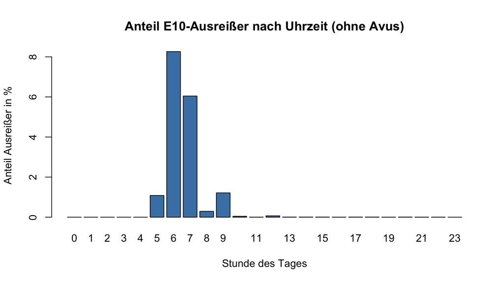

```r
barplot(100 * anteil_stunde,
        main = "Anteil E10-Ausreißer nach Uhrzeit (ohne Avus)",
        xlab = "Stunde des Tages",
        ylab = "Anteil Ausreißer in %",
        col = "steelblue")
```

```r
monat <- substr(ohne_avus$date, 1, 7)
round(100 * tapply(ohne_avus$ausr_e10, monat, sum) / tapply(!is.na(ohne_avus$e10_median), monat, sum), 1)
```

```
## 2025-02 2025-03 2025-04 2025-05 2025-06 2025-07 2025-08 2025-09 2025-10 2025-11
##     4.7     0.6     0.1     0.1     0.2     0.0     0.0     0.0     0.0     0.0
## 2025-12 2026-01
##     0.0     4.5
```

```r
round(100 * tapply(ohne_avus$ausr_diesel, monat, sum) / tapply(!is.na(ohne_avus$diesel_median), monat, sum), 1)
```

```
## 2025-02 2025-03 2025-04 2025-05 2025-06 2025-07 2025-08 2025-09 2025-10 2025-11
##     0.9     0.0     0.0     0.0     0.2     0.0     0.0     0.0     0.0     0.0
## 2025-12 2026-01
##     0.0     9.0
```

Dabei sieht man zwei Muster:

1. Uhrzeit: Die meisten Ausreißer gibt es um 6 und 7 Uhr morgens, bei E10 und Diesel (etwa 6 bis 8 % der Preise in diesen Stunden, nachmittags fast keine). Das passt dazu, dass die Preise morgens am höchsten sind und im Laufe des Tages sinken.
2. Monat: Viele Ausreißer gibt es im Februar 2025 und im Januar 2026, bei Diesel vor allem im Januar 2026. In diesen Monaten waren die Preise allgemein höher. Das sieht man im Verlauf des Tagesmedians unten, vor allem nach dem Jahreswechsel 2025/26, als beide Sorten auf etwa 1,68 € steigen:

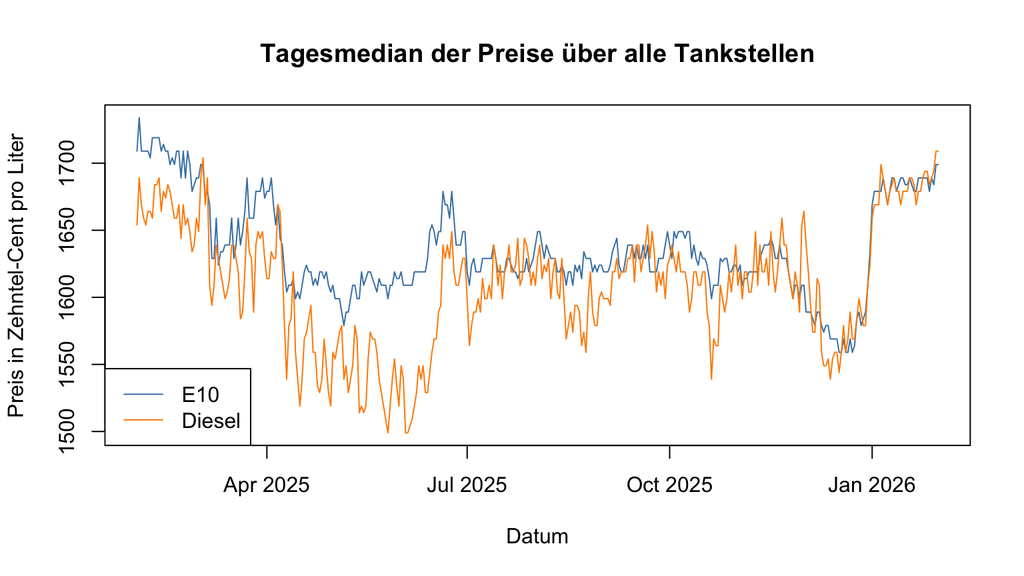

```r
tagesmedian_e10    <- tapply(tanken$e10_median, tanken$date, median, na.rm = TRUE)
tagesmedian_diesel <- tapply(tanken$diesel_median, tanken$date, median, na.rm = TRUE)
tage_datum <- as.Date(names(tagesmedian_e10))

plot(tage_datum, tagesmedian_e10, type = "l", col = "steelblue",
     ylim = range(c(tagesmedian_e10, tagesmedian_diesel)),
     main = "Tagesmedian der Preise über alle Tankstellen",
     xlab = "Datum", ylab = "Preis in Zehntel-Cent pro Liter")
lines(tage_datum, tagesmedian_diesel, col = "darkorange")
legend("bottomleft", legend = c("E10", "Diesel"), col = c("steelblue", "darkorange"), lty = 1)
```

Die wenigen Diesel-Ausreißer nach unten sind fast alle vom 3. und 4. Juni 2025. Da war Diesel insgesamt besonders billig:

```r
unten <- tanken$ausr_diesel & tanken$diesel_median < grenzen_diesel[1]
table(tanken$date[unten])
```

```
##
## 2025-04-16 2025-05-08 2025-05-23 2025-05-25 2025-06-03 2025-06-04
##          1          5          2          1         57         18
```

```r
length(unique(tanken$id[unten]))   # Anzahl verschiedener Tankstellen
```

```
## [1] 18
```

Sie kommen von 18 verschiedenen Tankstellen und mehreren Marken (z. B. JET, star, Sprint, ENI). Der Tagesmedian von Diesel erreicht am 3. und 4. Juni mit 1,499 € seinen tiefsten Wert im ganzen Jahr (genauso tief war er nur noch am 26. Mai). Es war also eine echte Preissenkung bei vielen Tankstellen und kein Fehler einer einzelnen Tankstelle.

#### Echte oder falsche Werte?

Alle bisherigen Muster kann man erklären: Autobahntankstellen sind teurer, morgens sind die Preise am höchsten und es gibt Zeiten, in denen die Preise allgemein höher oder niedriger sind. Diese Ausreißer sind also echte Werte. Sie sind ungewöhnlich, wurden aber wirklich so verlangt und sollten nicht gelöscht werden.

Anders ist es beim höchsten E10-Preis. Wir schauen uns diesen Wert zusammen mit den anderen Stunden am selben Tag an:

```r
i <- which.max(tanken$e10_median)
tanken[i, c("name", "street", "date", "time", "e10_median", "diesel_median")]
```

```
##                   name               street       date  time e10_median
## 376190 Esso Tankstelle MARIENDORFER DAMM 44 2025-02-21 17:00       2669
##        diesel_median
## 376190          2619
```

```r
tanken[tanken$id == tanken$id[i] & tanken$date == tanken$date[i],
       c("time", "e10_median", "diesel_median")]
```

```
##         time e10_median diesel_median
## 376180 06:00       1839          1799
## 376181 07:00       1829          1789
## 376182 08:00       1799          1739
## 376183 09:00       1759          1719
## 376184 10:00       1739          1689
## 376185 11:00       1714          1659
## 376186 12:00       1709          1659
## 376187 14:00       1729          1669
## 376188 15:00       1714          1654
## 376189 16:00       1709          1639
## 376190 17:00       2669          2619
## 376191 18:00       2289          2239
## 376192 19:00       1709          1619
## 376193 20:00       1699          1649
## 376194 21:00       1699          1624
## 376195 22:00       1699          1624
```

Um zu prüfen, ob es noch mehr solche Sprünge gibt, vergleichen wir jeden Preis mit dem Median derselben Tankstelle am selben Tag. Gesucht sind alle Preise, die mindestens 25 Cent davon abweichen:

```r
tagesmed_e10 <- ave(tanken$e10_median, tanken$id, tanken$date,
                    FUN = function(x) median(x, na.rm = TRUE))
sprung <- which(abs(tanken$e10_median - tagesmed_e10) >= 250)
tanken[sprung, c("name", "street", "date", "time", "e10_median", "diesel_median")]
```

```
##                   name               street       date  time e10_median
## 376190 Esso Tankstelle MARIENDORFER DAMM 44 2025-02-21 17:00       2669
## 376191 Esso Tankstelle MARIENDORFER DAMM 44 2025-02-21 18:00       2289
##        diesel_median
## 376190          2619
## 376191          2239
```

Es kommen nur die zwei Werte der ESSO heraus. Alle anderen Ausreißer entstehen also nicht durch einzelne Sprünge, sondern durch dauerhaft hohe Preise (Avus) oder durch allgemeine Preisänderungen.

Fazit: Fast alle Ausreißer sind echte Werte. Sie kommen von der Autobahntankstelle Avus, von den hohen Preisen am Morgen und aus Zeiten mit allgemein hohen (Februar 2025, Januar 2026) oder niedrigen Preisen (Anfang Juni 2025). Falsch sind nur einzelne Werte, nämlich die Preissprünge bei der ESSO am 21.02.2025 und die Dieselpreise von 0 aus Teilaufgabe a.

### Woche 4

1. Fügen Sie Ihrer Tabelle eine neue Spalte mit dem Wochentag hinzu. Generieren Sie Boxplots der Merkmale `e10_median` und `diesel_median` für jeden Wochentag und stellen die sieben Boxplots für jeden der Kraftstoffe nebeneinander. Interpretieren Sie die Preisunterschiede zwischen den Wochentagen und den Kraftstoffen.
2. Generieren Sie Boxplots der Merkmale `e10_median` und `diesel_median` für jede Uhrzeit (`time`) und stellen die stündlichen Boxplots für jeden der Kraftstoffe nebeneinander. Interpretieren Sie die Preisunterschiede zwischen den Uhrzeiten und den Kraftstoffen.
3. Generieren Sie Boxplots der Merkmale `e10_median` und `diesel_median` für jede Marke (`brand`) und stellen die Boxplots der Marken für jeden der Kraftstoffe nebeneinander. Interpretieren Sie die Preisunterschiede zwischen den Marken und den Kraftstoffen.
4. Welches der Merkmale hat nach obigen Analysen den stärksten Einfluss auf die Preise von E10 und Diesel? Begründen Sie die Antwort mit Hilfe der Boxplots und absoluten Messungen der Preisunterschiede.

### a. Wochentag

```r
tanken$wochentag <- format(as.Date(tanken$date), "%u")
table(tanken$wochentag)
```

```
##
##     1     2     3     4     5     6     7
## 68945 69007 69003 69036 69052 67257 65974
```

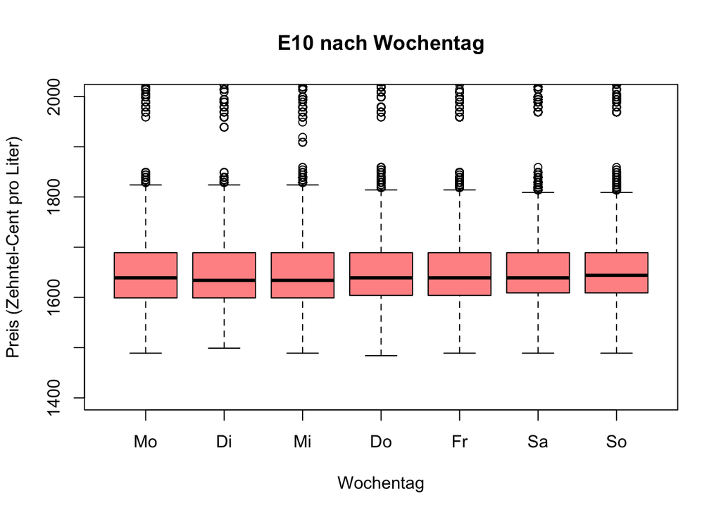

```r
boxplot(tanken$e10_median ~ tanken$wochentag,
        names = c("Mo", "Di", "Mi", "Do", "Fr", "Sa", "So"),
        main = "E10 nach Wochentag",
        xlab = "Wochentag",
        ylab = "Preis (Zehntel-Cent pro Liter)",
        ylim = c(1400, 2000),
         col =  rgb(1, 0, 0, 0.5))
```

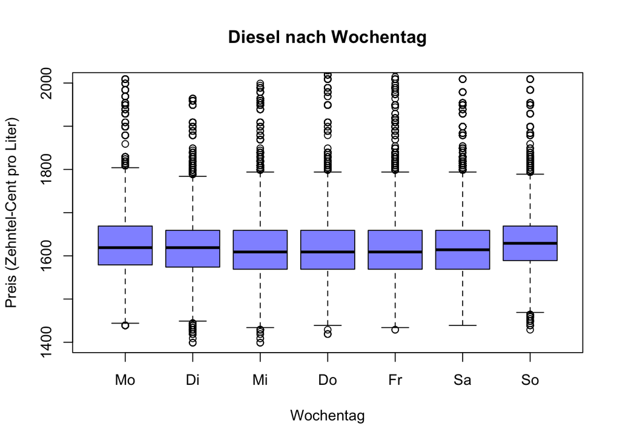

```r
boxplot(tanken$diesel_median ~ tanken$wochentag,
        names = c("Mo", "Di", "Mi", "Do", "Fr", "Sa", "So"),
        main = "Diesel nach Wochentag",
        xlab = "Wochentag",
        ylab = "Preis (Zehntel-Cent pro Liter)",
        ylim = c(1400, 2000),
         col = rgb(0, 0, 1, 0.5))
```

Die Boxplots sehen an allen Wochentagen fast gleich aus. Die Preise unterscheiden sich also kaum zwischen den Tagen.

```r
tapply(tanken$e10_median, tanken$wochentag, median, na.rm = TRUE)
```

```
##    1    2    3    4    5    6    7
## 1639 1634 1634 1639 1639 1639 1644
```

```r
tapply(tanken$diesel_median, tanken$wochentag, median, na.rm = TRUE)
```

```
##    1    2    3    4    5    6    7
## 1619 1619 1609 1609 1609 1614 1629
```

### b. Uhrzeiten

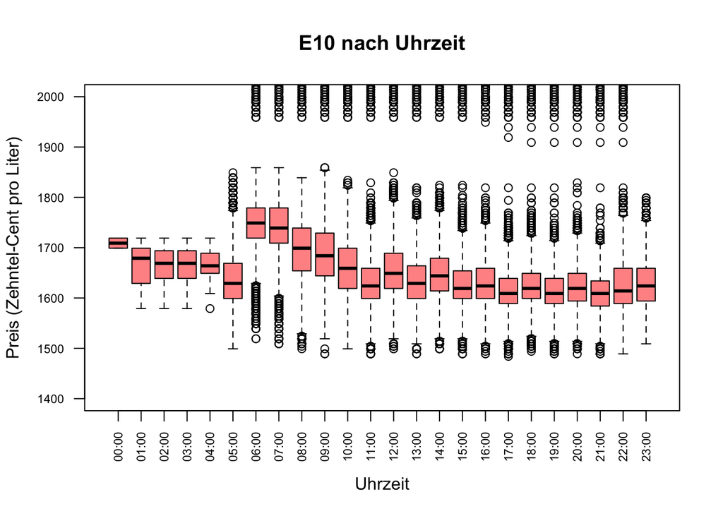

```r
boxplot(tanken$e10_median ~ tanken$time,
        main = "E10 nach Uhrzeit",
        xlab = "Uhrzeit",
        ylab = "Preis (Zehntel-Cent pro Liter)",
        ylim = c(1400, 2000),
        las = 2, cex.axis = 0.7,
        col = rgb(1, 0, 0, 0.5))
```

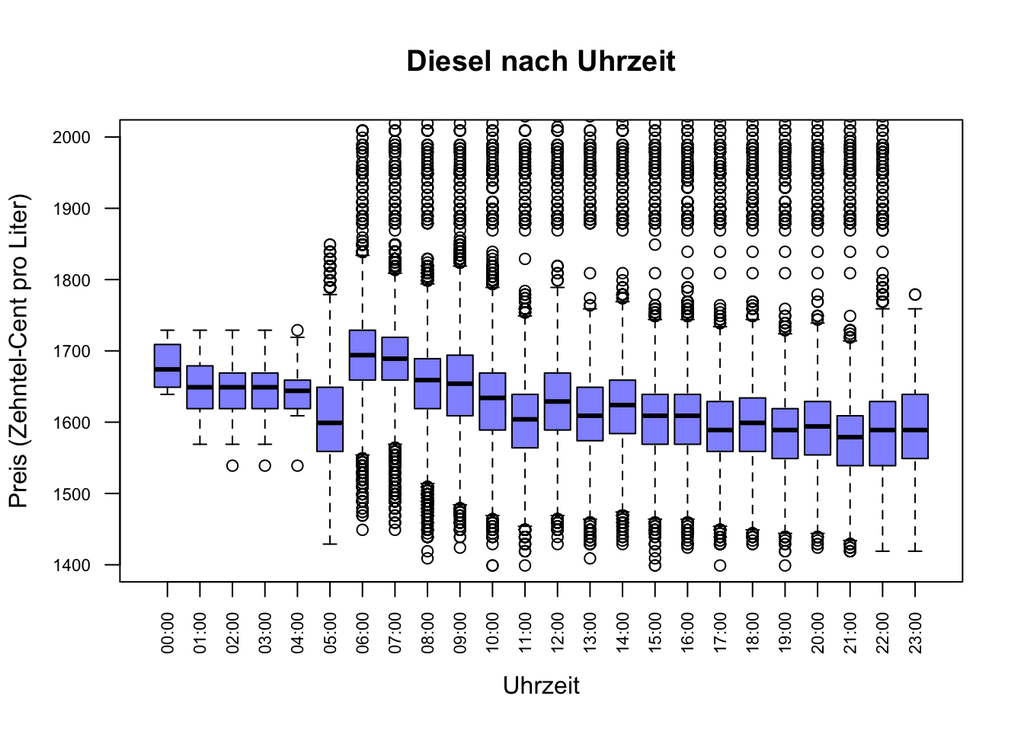

```r
boxplot(tanken$diesel_median ~ tanken$time,
        main = "Diesel nach Uhrzeit",
        xlab = "Uhrzeit",
        ylab = "Preis (Zehntel-Cent pro Liter)",
        ylim = c(1400, 2000),
        las = 2, cex.axis = 0.7,
        col = rgb(0, 0, 1, 0.5))
```

```r
tapply(tanken$e10_median, tanken$time, median, na.rm = TRUE)
```

```
## 00:00 01:00 02:00 03:00 04:00 05:00 06:00 07:00 08:00 09:00 10:00 11:00 12:00
##  1709  1679  1669  1669  1664  1629  1749  1739  1699  1684  1659  1624  1649
## 13:00 14:00 15:00 16:00 17:00 18:00 19:00 20:00 21:00 22:00 23:00
##  1629  1644  1619  1624  1609  1619  1609  1619  1609  1614  1624
```

```r
tapply(tanken$diesel_median, tanken$time, median, na.rm = TRUE)
```

```
## 00:00 01:00 02:00 03:00 04:00 05:00 06:00 07:00 08:00 09:00 10:00 11:00 12:00
##  1674  1649  1649  1649  1644  1599  1694  1689  1659  1654  1634  1604  1629
## 13:00 14:00 15:00 16:00 17:00 18:00 19:00 20:00 21:00 22:00 23:00
##  1609  1624  1609  1609  1589  1599  1589  1594  1579  1589  1589
```

morgens am teuersten Die Preise sinken in Laufe des Tages

## Quellen

[1] Tankerkönig UG, URL: https://tankerkoenig.de, letzter Aufruf: 02.11.2026